# Import the libraries and load the data

```python
import warnings
warnings.filterwarnings("ignore")

# Libraries to help with reading and manipulating data

import pandas as pd
import numpy as np

# Library to split data
from sklearn.model_selection import train_test_split

# libaries to help with data visualization
import matplotlib.pyplot as plt
import seaborn as sns

# Removes the limit from the number of displayed columns and rows.
pd.set_option("display.max_columns", None)
pd.set_option("display.max_rows", 200)
```

```python
# Let's make sure the graphs look nice and are displayed immediately instead of explicitly
sns.set(color_codes=True)
%matplotlib inline
```

```python
# Now get the libraries needed for Logistic Regression
from sklearn.linear_model import LogisticRegression

# To get diferent metric scores
from sklearn import metrics
from sklearn.metrics import f1_score, accuracy_score, recall_score, precision_score, roc_auc_score, roc_curve, confusion_matrix, precision_recall_curve
```

```python
# Now get the libraries needed for Decision Tree
from sklearn.tree import DecisionTreeClassifier
from sklearn import tree
from sklearn.model_selection import GridSearchCV
```

```python
# Load the data
orig = pd.read_csv("Loan_Modelling.csv")
```

```python
# Make a copy to keep the original data safe
df = orig.copy()
```

# Exploratory Data Analysis

```python
df.shape
```

```
(5000, 14)
```

### We have 5000 records and 14 columns.

Let's take a look at the data to get a feel for what it looks like

```python
df.head(15) # first 15 rows
```

|  | ID | Age | Experience | Income | ZIPCode | Family | CCAvg | Education | Mortgage | Personal_Loan | Securities_Account | CD_Account | Online | CreditCard |
| --- | --- | --- | --- | --- | --- | --- | --- | --- | --- | --- | --- | --- | --- | --- |
| 0 | 1 | 25 | 1 | 49 | 91107 | 4 | 1.6 | 1 | 0 | 0 | 1 | 0 | 0 | 0 |
| 1 | 2 | 45 | 19 | 34 | 90089 | 3 | 1.5 | 1 | 0 | 0 | 1 | 0 | 0 | 0 |
| 2 | 3 | 39 | 15 | 11 | 94720 | 1 | 1.0 | 1 | 0 | 0 | 0 | 0 | 0 | 0 |
| 3 | 4 | 35 | 9 | 100 | 94112 | 1 | 2.7 | 2 | 0 | 0 | 0 | 0 | 0 | 0 |
| 4 | 5 | 35 | 8 | 45 | 91330 | 4 | 1.0 | 2 | 0 | 0 | 0 | 0 | 0 | 1 |
| 5 | 6 | 37 | 13 | 29 | 92121 | 4 | 0.4 | 2 | 155 | 0 | 0 | 0 | 1 | 0 |
| 6 | 7 | 53 | 27 | 72 | 91711 | 2 | 1.5 | 2 | 0 | 0 | 0 | 0 | 1 | 0 |
| 7 | 8 | 50 | 24 | 22 | 93943 | 1 | 0.3 | 3 | 0 | 0 | 0 | 0 | 0 | 1 |
| 8 | 9 | 35 | 10 | 81 | 90089 | 3 | 0.6 | 2 | 104 | 0 | 0 | 0 | 1 | 0 |
| 9 | 10 | 34 | 9 | 180 | 93023 | 1 | 8.9 | 3 | 0 | 1 | 0 | 0 | 0 | 0 |
| 10 | 11 | 65 | 39 | 105 | 94710 | 4 | 2.4 | 3 | 0 | 0 | 0 | 0 | 0 | 0 |
| 11 | 12 | 29 | 5 | 45 | 90277 | 3 | 0.1 | 2 | 0 | 0 | 0 | 0 | 1 | 0 |
| 12 | 13 | 48 | 23 | 114 | 93106 | 2 | 3.8 | 3 | 0 | 0 | 1 | 0 | 0 | 0 |
| 13 | 14 | 59 | 32 | 40 | 94920 | 4 | 2.5 | 2 | 0 | 0 | 0 | 0 | 1 | 0 |
| 14 | 15 | 67 | 41 | 112 | 91741 | 1 | 2.0 | 1 | 0 | 0 | 1 | 0 | 0 | 0 |

```python
df.tail(15) # last 15 rows
```

|  | ID | Age | Experience | Income | ZIPCode | Family | CCAvg | Education | Mortgage | Personal_Loan | Securities_Account | CD_Account | Online | CreditCard |
| --- | --- | --- | --- | --- | --- | --- | --- | --- | --- | --- | --- | --- | --- | --- |
| 4985 | 4986 | 48 | 23 | 30 | 94720 | 3 | 1.70 | 2 | 162 | 0 | 0 | 0 | 1 | 0 |
| 4986 | 4987 | 32 | 6 | 78 | 95825 | 1 | 2.90 | 3 | 0 | 0 | 0 | 0 | 0 | 0 |
| 4987 | 4988 | 48 | 23 | 43 | 93943 | 3 | 1.70 | 2 | 159 | 0 | 0 | 0 | 1 | 0 |
| 4988 | 4989 | 34 | 8 | 85 | 95134 | 1 | 2.50 | 1 | 136 | 0 | 0 | 0 | 0 | 1 |
| 4989 | 4990 | 24 | 0 | 38 | 93555 | 1 | 1.00 | 3 | 0 | 0 | 0 | 0 | 1 | 0 |
| 4990 | 4991 | 55 | 25 | 58 | 95023 | 4 | 2.00 | 3 | 219 | 0 | 0 | 0 | 0 | 1 |
| 4991 | 4992 | 51 | 25 | 92 | 91330 | 1 | 1.90 | 2 | 100 | 0 | 0 | 0 | 0 | 1 |
| 4992 | 4993 | 30 | 5 | 13 | 90037 | 4 | 0.50 | 3 | 0 | 0 | 0 | 0 | 0 | 0 |
| 4993 | 4994 | 45 | 21 | 218 | 91801 | 2 | 6.67 | 1 | 0 | 0 | 0 | 0 | 1 | 0 |
| 4994 | 4995 | 64 | 40 | 75 | 94588 | 3 | 2.00 | 3 | 0 | 0 | 0 | 0 | 1 | 0 |
| 4995 | 4996 | 29 | 3 | 40 | 92697 | 1 | 1.90 | 3 | 0 | 0 | 0 | 0 | 1 | 0 |
| 4996 | 4997 | 30 | 4 | 15 | 92037 | 4 | 0.40 | 1 | 85 | 0 | 0 | 0 | 1 | 0 |
| 4997 | 4998 | 63 | 39 | 24 | 93023 | 2 | 0.30 | 3 | 0 | 0 | 0 | 0 | 0 | 0 |
| 4998 | 4999 | 65 | 40 | 49 | 90034 | 3 | 0.50 | 2 | 0 | 0 | 0 | 0 | 1 | 0 |
| 4999 | 5000 | 28 | 4 | 83 | 92612 | 3 | 0.80 | 1 | 0 | 0 | 0 | 0 | 1 | 1 |

#### Observation

The following columns have boolean data

- Personal_Loan
- Securities_Account
- CD_Account
- Online
- CreditCard

However, the data is not in the form of True/False. Assuming that 0 represents False, and 1 represents True.

```python
# Let's check if there is any missing data
df[df.isnull()].count()
```

```
ID                    0
Age                   0
Experience            0
Income                0
ZIPCode               0
Family                0
CCAvg                 0
Education             0
Mortgage              0
Personal_Loan         0
Securities_Account    0
CD_Account            0
Online                0
CreditCard            0
dtype: int64
```

```python
# Let's look at the datatypes of the various features
df.info()
```

```
<class 'pandas.core.frame.DataFrame'>
RangeIndex: 5000 entries, 0 to 4999
Data columns (total 14 columns):
 #   Column              Non-Null Count  Dtype
---  ------              --------------  -----
 0   ID                  5000 non-null   int64
 1   Age                 5000 non-null   int64
 2   Experience          5000 non-null   int64
 3   Income              5000 non-null   int64
 4   ZIPCode             5000 non-null   int64
 5   Family              5000 non-null   int64
 6   CCAvg               5000 non-null   float64
 7   Education           5000 non-null   int64
 8   Mortgage            5000 non-null   int64
 9   Personal_Loan       5000 non-null   int64
 10  Securities_Account  5000 non-null   int64
 11  CD_Account          5000 non-null   int64
 12  Online              5000 non-null   int64
 13  CreditCard          5000 non-null   int64
dtypes: float64(1), int64(13)
memory usage: 547.0 KB
```

There doesn't appear to be any missing data. In fact, on the face of it the data looks remarkably clean. All columns are numeric, so there are no unexpected characters or anything that can make the datatype into an 'object'.

So next we have to see the ranges of the data to get a feel for outliers, central tendency, etc.

```python
df.describe().T
```

|  | count | mean | std | min | 25% | 50% | 75% | max |
| --- | --- | --- | --- | --- | --- | --- | --- | --- |
| ID | 5000.0 | 2500.500000 | 1443.520003 | 1.0 | 1250.75 | 2500.5 | 3750.25 | 5000.0 |
| Age | 5000.0 | 45.338400 | 11.463166 | 23.0 | 35.00 | 45.0 | 55.00 | 67.0 |
| Experience | 5000.0 | 20.104600 | 11.467954 | -3.0 | 10.00 | 20.0 | 30.00 | 43.0 |
| Income | 5000.0 | 73.774200 | 46.033729 | 8.0 | 39.00 | 64.0 | 98.00 | 224.0 |
| ZIPCode | 5000.0 | 93169.257000 | 1759.455086 | 90005.0 | 91911.00 | 93437.0 | 94608.00 | 96651.0 |
| Family | 5000.0 | 2.396400 | 1.147663 | 1.0 | 1.00 | 2.0 | 3.00 | 4.0 |
| CCAvg | 5000.0 | 1.937938 | 1.747659 | 0.0 | 0.70 | 1.5 | 2.50 | 10.0 |
| Education | 5000.0 | 1.881000 | 0.839869 | 1.0 | 1.00 | 2.0 | 3.00 | 3.0 |
| Mortgage | 5000.0 | 56.498800 | 101.713802 | 0.0 | 0.00 | 0.0 | 101.00 | 635.0 |
| Personal_Loan | 5000.0 | 0.096000 | 0.294621 | 0.0 | 0.00 | 0.0 | 0.00 | 1.0 |
| Securities_Account | 5000.0 | 0.104400 | 0.305809 | 0.0 | 0.00 | 0.0 | 0.00 | 1.0 |
| CD_Account | 5000.0 | 0.060400 | 0.238250 | 0.0 | 0.00 | 0.0 | 0.00 | 1.0 |
| Online | 5000.0 | 0.596800 | 0.490589 | 0.0 | 0.00 | 1.0 | 1.00 | 1.0 |
| CreditCard | 5000.0 | 0.294000 | 0.455637 | 0.0 | 0.00 | 0.0 | 1.00 | 1.0 |

We have the following observations

- Age is in the range 23 to 67, with the mean and median both at 45. This is a normal distribution.
- Experience appears to have some bad data as we see the min experience as -3. This needs to be looked at some more.
- Income is in the range USD 8000 to USD 224,000 with mean at USD 74K and median at USD 64K. Means data is right-skewed.
- All family sizes are fairly small ranging from 1 person to 4 people.
- CCAvg has a range from USD 0 to USD 10,000, with mean and median close to USD 2000. So this is also right skewed data.
- Mortgage ranges from USD 0 to USD 635,000.

```python
# Check for duplicate data
df[df.duplicated()].count()
```

```
ID                    0
Age                   0
Experience            0
Income                0
ZIPCode               0
Family                0
CCAvg                 0
Education             0
Mortgage              0
Personal_Loan         0
Securities_Account    0
CD_Account            0
Online                0
CreditCard            0
dtype: int64
```

So there is no duplicate data that needs to be cleaned up

## Univariate Analysis

#### Next we can look at some univariate analysis of the various features to get a feel for the distribution of data.

- For the boolean and categorical data, we will look at valuecounts to get a feel for the distribution.
- For the continuous variables, histograms and boxplots will be more useful.

```python
# Let's get value counts for the columns that are really categorical data encoded as numerics.
cat_cols = ['ZIPCode', 'Family', 'Education', 'Securities_Account', 'CD_Account', 'Online', 'CreditCard', 'Personal_Loan']
for i in cat_cols:
    print("==>", i)
    print(df[i].value_counts())
```

```
==> ZIPCode
94720    169
94305    127
95616    116
90095     71
93106     57
        ...
94087      1
96145      1
90068      1
92694      1
94404      1
Name: ZIPCode, Length: 467, dtype: int64
==> Family
1    1472
2    1296
4    1222
3    1010
Name: Family, dtype: int64
==> Education
1    2096
3    1501
2    1403
Name: Education, dtype: int64
==> Securities_Account
0    4478
1     522
Name: Securities_Account, dtype: int64
==> CD_Account
0    4698
1     302
Name: CD_Account, dtype: int64
==> Online
1    2984
0    2016
Name: Online, dtype: int64
==> CreditCard
0    3530
1    1470
Name: CreditCard, dtype: int64
==> Personal_Loan
0    4520
1     480
Name: Personal_Loan, dtype: int64
```

### Observations

- Customers come from 467 different zip codes. Some have a lot more customers than others. This may indicate rural vs. urban distribution of customers.
- Families of various sizes almost evenly distributed
- Education level of people is fairly equally distributed, but slightly higher for undergrads, which is expected.
- About 10% of people own securities account, and an even smaller number own CD accounts.
- About one-third of the population has a credit card from another bank.
- Only about 10% of people reponded to personal loans

### Let's take a countplot of some of these features to visually observe the values.

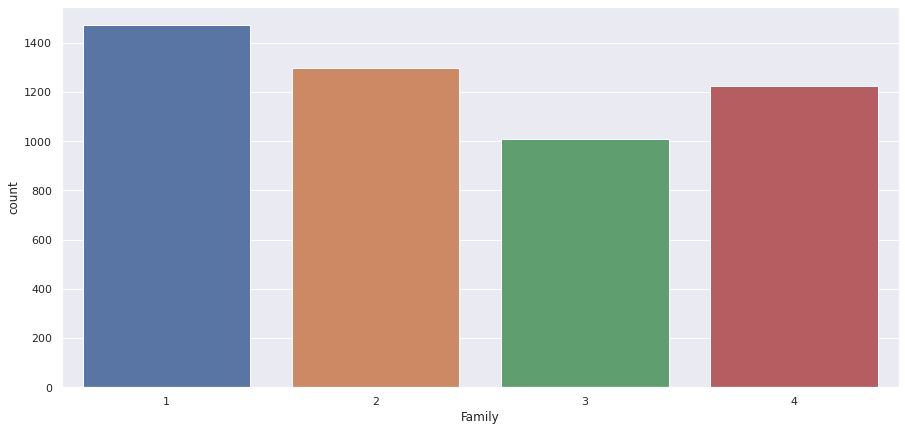

```python
plt.figure(figsize=(15, 7))
sns.countplot(x="Family", data=df);
```

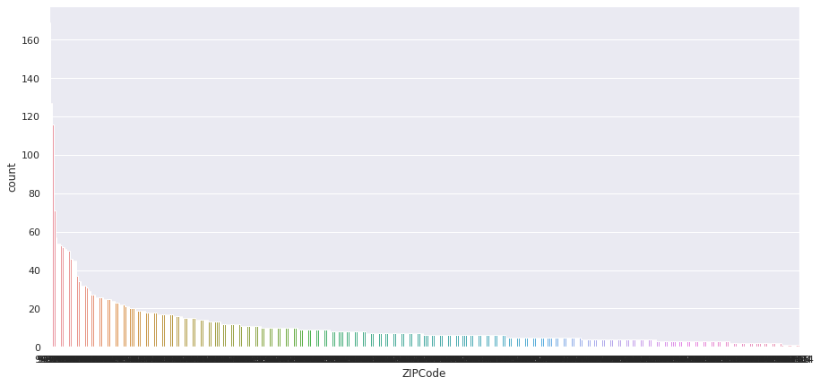

```python
plt.figure(figsize=(15, 7))
sns.countplot(x="ZIPCode", data=df, order=df["ZIPCode"].value_counts().index);
```

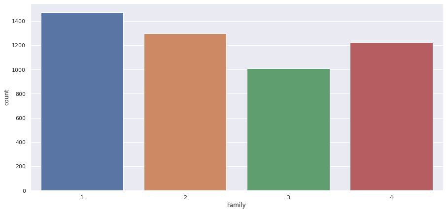

```python
plt.figure(figsize=(15, 7))
sns.countplot(x="Family", data=df);
```

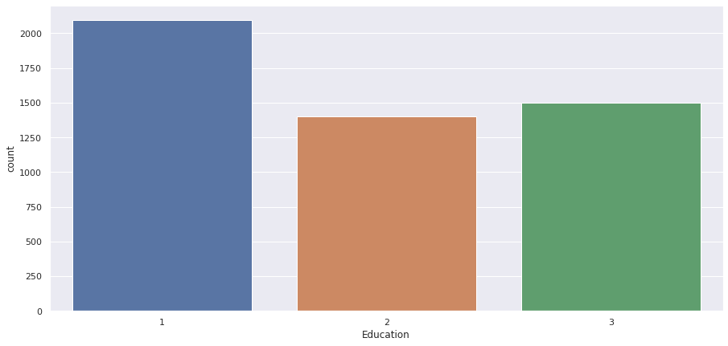

```python
plt.figure(figsize=(15, 7))
sns.countplot(x="Education", data=df);
```

#### To draw the histograms and boxplots for the univariate analysis, I am going to make use of a handy function that Jitendra gave us during the MLS sessions where the two plots are drawn as subplots one on top of the other.

```python
# This code has been adapted from the code that Jitendra presented during the MLS sessions.
# Original credit for this function goes to Jitendra.
#
# This allows for the display of a histogram as well as box plot of the same feature for univariate analysis.

def showHistBox(feature, figsize=(15, 10), bins=None):
    f2, (ax_box2, ax_hist2) = plt.subplots(
        nrows=2,  # Number of rows of the subplot grid= 2
        sharex=True,  # x-axis will be shared among all subplots
        gridspec_kw={"height_ratios": (0.25, 0.75)},
        figsize=figsize,
    )  # creating the 2 subplots
    sns.boxplot(
        feature, ax=ax_box2, showmeans=True, color="green"
    )  # boxplot will be created and a star will indicate the mean value of the column
    sns.displot(
        feature, kde=F, ax=ax_hist2, bins=bins, palette="winter"
    ) if bins else sns.distplot(
        feature, kde=False, ax=ax_hist2
    )  # For histogram
    ax_hist2.axvline(
        np.mean(feature), color="green", linestyle="--"
    )  # Add mean to the histogram
    ax_hist2.axvline(
        np.median(feature), color="black", linestyle="-"
    )  # Add median to the histogram
```

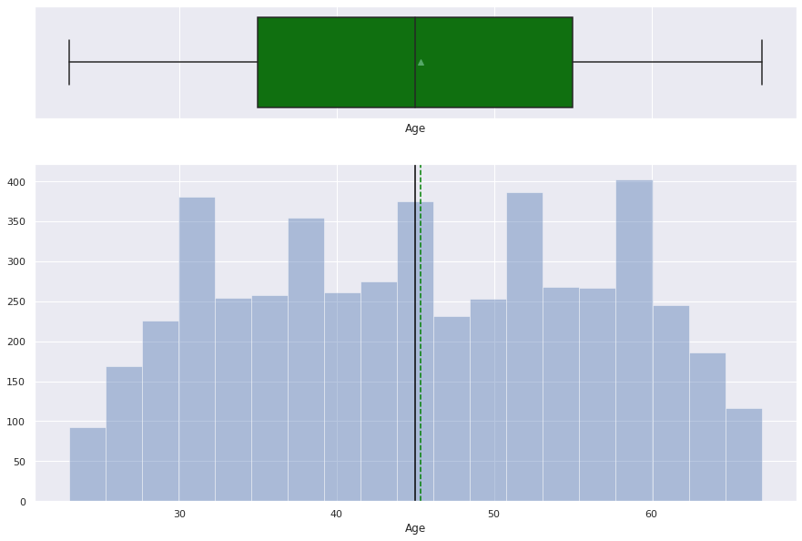

```python
showHistBox(df.Age)
```

### Age

The distribution of Age is a normal distribution with no outliers. We don't need to do any cleanup of the data.

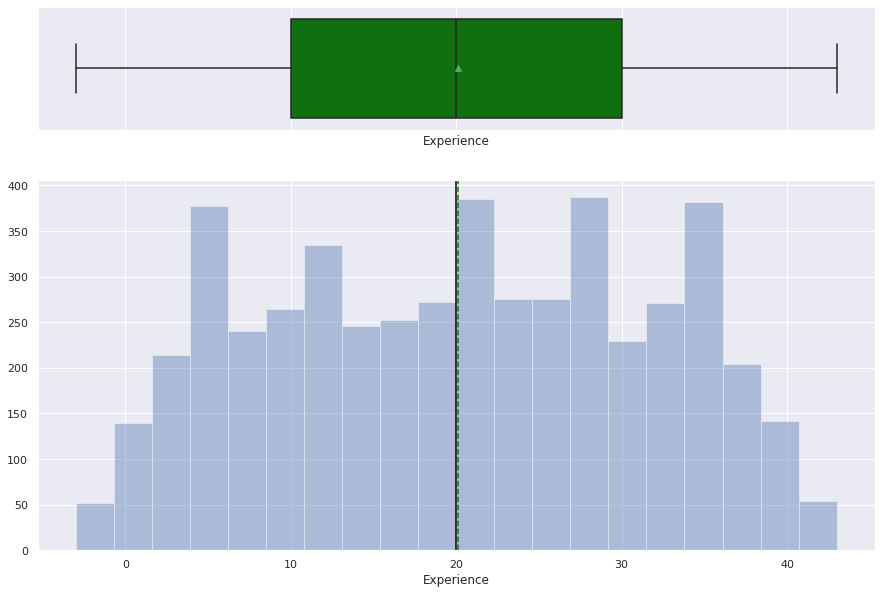

```python
showHistBox(df.Experience)
```

### Experience

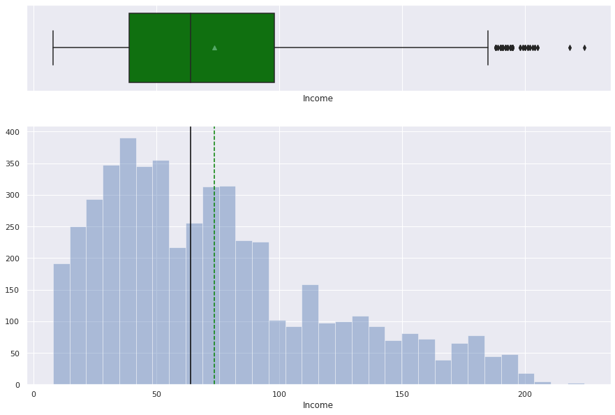

```python
showHistBox(df.Income)
```

### Income

There are some outliers in the Income data, but these appear to be not out of the ordinary. The distribution is mostly normal with a right skew. I don't think there is a need to reject any of the records.

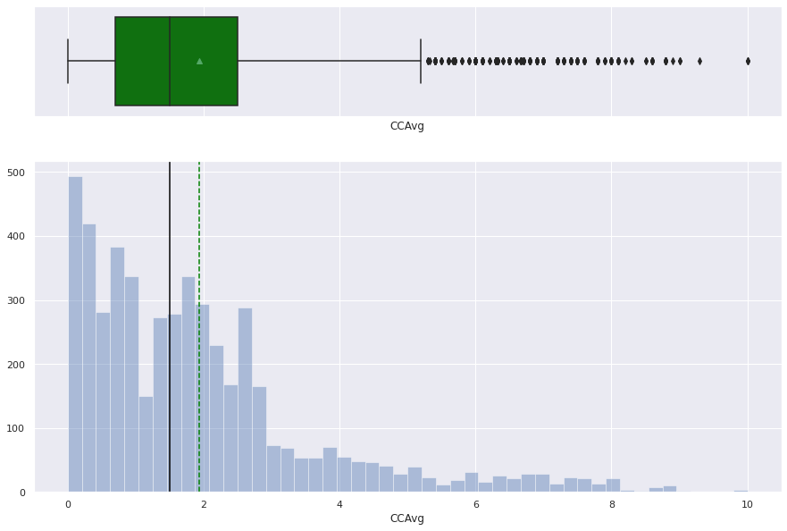

```python
showHistBox(df.CCAvg)
```

### CCAvg

There are some outliers in the credit-card average data, but these appear to be not out of the ordinary. The distribution has a strong right skew, but all data appears to be relevant. I don't think there is a need to reject any of the records.

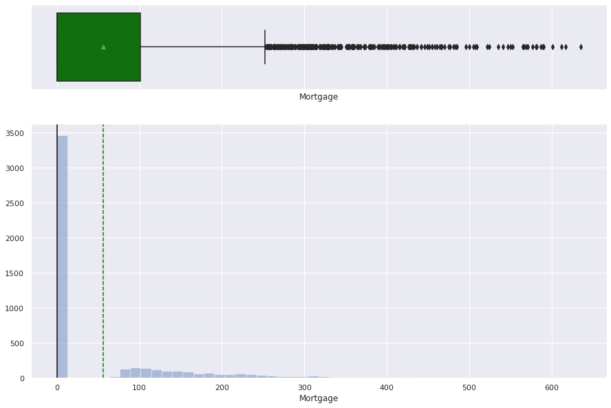

```python
showHistBox(df.Mortgage)
```

### Mortgage

Most of the mortgage data is a balance of USD 0. Then there is a sharp dropoff and then there are a whole bunch of outliers. However, since the data has 0's in it, it is not possible to do a log scale transformation.

### Analysis of the Experience data with the negative experience levels.

We need to investigate the nature of the data for the set of records where experience level is a negative number.

```python
df[df['Experience']<0].count()
```

```
ID                    52
Age                   52
Experience            52
Income                52
ZIPCode               52
Family                52
CCAvg                 52
Education             52
Mortgage              52
Personal_Loan         52
Securities_Account    52
CD_Account            52
Online                52
CreditCard            52
dtype: int64
```

```python
df[df['Experience']<0]
```

|  | ID | Age | Experience | Income | ZIPCode | Family | CCAvg | Education | Mortgage | Personal_Loan | Securities_Account | CD_Account | Online | CreditCard |
| --- | --- | --- | --- | --- | --- | --- | --- | --- | --- | --- | --- | --- | --- | --- |
| 89 | 90 | 25 | -1 | 113 | 94303 | 4 | 2.30 | 3 | 0 | 0 | 0 | 0 | 0 | 1 |
| 226 | 227 | 24 | -1 | 39 | 94085 | 2 | 1.70 | 2 | 0 | 0 | 0 | 0 | 0 | 0 |
| 315 | 316 | 24 | -2 | 51 | 90630 | 3 | 0.30 | 3 | 0 | 0 | 0 | 0 | 1 | 0 |
| 451 | 452 | 28 | -2 | 48 | 94132 | 2 | 1.75 | 3 | 89 | 0 | 0 | 0 | 1 | 0 |
| 524 | 525 | 24 | -1 | 75 | 93014 | 4 | 0.20 | 1 | 0 | 0 | 0 | 0 | 1 | 0 |
| 536 | 537 | 25 | -1 | 43 | 92173 | 3 | 2.40 | 2 | 176 | 0 | 0 | 0 | 1 | 0 |
| 540 | 541 | 25 | -1 | 109 | 94010 | 4 | 2.30 | 3 | 314 | 0 | 0 | 0 | 1 | 0 |
| 576 | 577 | 25 | -1 | 48 | 92870 | 3 | 0.30 | 3 | 0 | 0 | 0 | 0 | 0 | 1 |
| 583 | 584 | 24 | -1 | 38 | 95045 | 2 | 1.70 | 2 | 0 | 0 | 0 | 0 | 1 | 0 |
| 597 | 598 | 24 | -2 | 125 | 92835 | 2 | 7.20 | 1 | 0 | 0 | 1 | 0 | 0 | 1 |
| 649 | 650 | 25 | -1 | 82 | 92677 | 4 | 2.10 | 3 | 0 | 0 | 0 | 0 | 1 | 0 |
| 670 | 671 | 23 | -1 | 61 | 92374 | 4 | 2.60 | 1 | 239 | 0 | 0 | 0 | 1 | 0 |
| 686 | 687 | 24 | -1 | 38 | 92612 | 4 | 0.60 | 2 | 0 | 0 | 0 | 0 | 1 | 0 |
| 793 | 794 | 24 | -2 | 150 | 94720 | 2 | 2.00 | 1 | 0 | 0 | 0 | 0 | 1 | 0 |
| 889 | 890 | 24 | -2 | 82 | 91103 | 2 | 1.60 | 3 | 0 | 0 | 0 | 0 | 1 | 1 |
| 909 | 910 | 23 | -1 | 149 | 91709 | 1 | 6.33 | 1 | 305 | 0 | 0 | 0 | 0 | 1 |
| 1173 | 1174 | 24 | -1 | 35 | 94305 | 2 | 1.70 | 2 | 0 | 0 | 0 | 0 | 0 | 0 |
| 1428 | 1429 | 25 | -1 | 21 | 94583 | 4 | 0.40 | 1 | 90 | 0 | 0 | 0 | 1 | 0 |
| 1522 | 1523 | 25 | -1 | 101 | 94720 | 4 | 2.30 | 3 | 256 | 0 | 0 | 0 | 0 | 1 |
| 1905 | 1906 | 25 | -1 | 112 | 92507 | 2 | 2.00 | 1 | 241 | 0 | 0 | 0 | 1 | 0 |
| 2102 | 2103 | 25 | -1 | 81 | 92647 | 2 | 1.60 | 3 | 0 | 0 | 0 | 0 | 1 | 1 |
| 2430 | 2431 | 23 | -1 | 73 | 92120 | 4 | 2.60 | 1 | 0 | 0 | 0 | 0 | 1 | 0 |
| 2466 | 2467 | 24 | -2 | 80 | 94105 | 2 | 1.60 | 3 | 0 | 0 | 0 | 0 | 1 | 0 |
| 2545 | 2546 | 25 | -1 | 39 | 94720 | 3 | 2.40 | 2 | 0 | 0 | 0 | 0 | 1 | 0 |
| 2618 | 2619 | 23 | -3 | 55 | 92704 | 3 | 2.40 | 2 | 145 | 0 | 0 | 0 | 1 | 0 |
| 2717 | 2718 | 23 | -2 | 45 | 95422 | 4 | 0.60 | 2 | 0 | 0 | 0 | 0 | 1 | 1 |
| 2848 | 2849 | 24 | -1 | 78 | 94720 | 2 | 1.80 | 2 | 0 | 0 | 0 | 0 | 0 | 0 |
| 2876 | 2877 | 24 | -2 | 80 | 91107 | 2 | 1.60 | 3 | 238 | 0 | 0 | 0 | 0 | 0 |
| 2962 | 2963 | 23 | -2 | 81 | 91711 | 2 | 1.80 | 2 | 0 | 0 | 0 | 0 | 0 | 0 |
| 2980 | 2981 | 25 | -1 | 53 | 94305 | 3 | 2.40 | 2 | 0 | 0 | 0 | 0 | 0 | 0 |
| 3076 | 3077 | 29 | -1 | 62 | 92672 | 2 | 1.75 | 3 | 0 | 0 | 0 | 0 | 0 | 1 |
| 3130 | 3131 | 23 | -2 | 82 | 92152 | 2 | 1.80 | 2 | 0 | 0 | 1 | 0 | 0 | 1 |
| 3157 | 3158 | 23 | -1 | 13 | 94720 | 4 | 1.00 | 1 | 84 | 0 | 0 | 0 | 1 | 0 |
| 3279 | 3280 | 26 | -1 | 44 | 94901 | 1 | 2.00 | 2 | 0 | 0 | 0 | 0 | 0 | 0 |
| 3284 | 3285 | 25 | -1 | 101 | 95819 | 4 | 2.10 | 3 | 0 | 0 | 0 | 0 | 0 | 1 |
| 3292 | 3293 | 25 | -1 | 13 | 95616 | 4 | 0.40 | 1 | 0 | 0 | 1 | 0 | 0 | 0 |
| 3394 | 3395 | 25 | -1 | 113 | 90089 | 4 | 2.10 | 3 | 0 | 0 | 0 | 0 | 1 | 0 |
| 3425 | 3426 | 23 | -1 | 12 | 91605 | 4 | 1.00 | 1 | 90 | 0 | 0 | 0 | 1 | 0 |
| 3626 | 3627 | 24 | -3 | 28 | 90089 | 4 | 1.00 | 3 | 0 | 0 | 0 | 0 | 0 | 0 |
| 3796 | 3797 | 24 | -2 | 50 | 94920 | 3 | 2.40 | 2 | 0 | 0 | 1 | 0 | 0 | 0 |
| 3824 | 3825 | 23 | -1 | 12 | 95064 | 4 | 1.00 | 1 | 0 | 0 | 1 | 0 | 0 | 1 |
| 3887 | 3888 | 24 | -2 | 118 | 92634 | 2 | 7.20 | 1 | 0 | 0 | 1 | 0 | 1 | 0 |
| 3946 | 3947 | 25 | -1 | 40 | 93117 | 3 | 2.40 | 2 | 0 | 0 | 0 | 0 | 1 | 0 |
| 4015 | 4016 | 25 | -1 | 139 | 93106 | 2 | 2.00 | 1 | 0 | 0 | 0 | 0 | 0 | 1 |
| 4088 | 4089 | 29 | -1 | 71 | 94801 | 2 | 1.75 | 3 | 0 | 0 | 0 | 0 | 0 | 0 |
| 4116 | 4117 | 24 | -2 | 135 | 90065 | 2 | 7.20 | 1 | 0 | 0 | 0 | 0 | 1 | 0 |
| 4285 | 4286 | 23 | -3 | 149 | 93555 | 2 | 7.20 | 1 | 0 | 0 | 0 | 0 | 1 | 0 |
| 4411 | 4412 | 23 | -2 | 75 | 90291 | 2 | 1.80 | 2 | 0 | 0 | 0 | 0 | 1 | 1 |
| 4481 | 4482 | 25 | -2 | 35 | 95045 | 4 | 1.00 | 3 | 0 | 0 | 0 | 0 | 1 | 0 |
| 4514 | 4515 | 24 | -3 | 41 | 91768 | 4 | 1.00 | 3 | 0 | 0 | 0 | 0 | 1 | 0 |
| 4582 | 4583 | 25 | -1 | 69 | 92691 | 3 | 0.30 | 3 | 0 | 0 | 0 | 0 | 1 | 0 |
| 4957 | 4958 | 29 | -1 | 50 | 95842 | 2 | 1.75 | 3 | 0 | 0 | 0 | 0 | 0 | 1 |

There doesn't seem to be anything particularly different about these set of 52 records. During data cleanup, we should convert all these experience level to 0.

### Bivariate Analysis

Let's use a HeatMap to look at multi-collinearity between the various features.

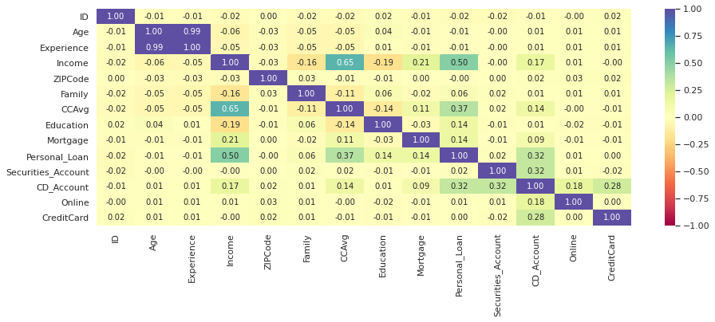

```python
plt.figure(figsize=(15,5))
sns.heatmap(df.corr(),annot=True,vmin=-1,vmax=1,fmt='.2f',cmap='Spectral')
plt.show()
```

### Observations

- There is a strong correlation between Experience and Age, at 0.99. We will need to drop one of the columns as input for the Personal_loan calculations.
- There is a fairly strong correlation between Income and CCAvg at 0.65. Not sure if one of the columns will need to be dropped.

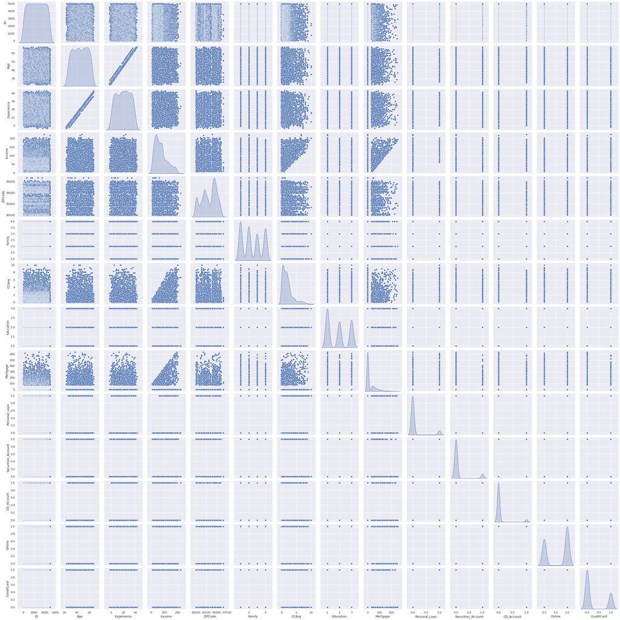

```python
# Let's also get a pairplot to see the correlation between the features
sns.pairplot(df, diag_kind='kde')
```

##### Note

- The lower half of the pairplot consists of categorical features, hence the multiple peaks we see in the histograms.
- We again see the streaight line correlation between Age and Experience.
- We do not see much correlation between the other features.

#### Next, we need to do some bivariate analysis to identify the relationships of some of the independent features with the dependent variable - personal loan.

### Bivariate analysis for some of the other categorical variables

For some of the next set of analysis, I will adapt a function given to us by Jitendra during the MLS sessions that plots a stacked chart. I have made the function more generic.

```python
### Function to plot stacked bar charts for categorical columns
def stacked_plot(x, y, sorting_value):
    sns.set()
    ## crosstab
    tab1 = pd.crosstab(x,y,margins=True).sort_values(by=sorting_value,ascending=False)
    print(tab1)
    print('-'*120)
    ## visualising the cross tab
    tab = pd.crosstab(x,y,normalize='index').sort_values(by=sorting_value,ascending=False)
    tab.plot(kind
             ='bar',stacked=True,figsize=(17,7))
    plt.legend(loc='lower left', frameon=False,)
    plt.legend(loc="upper left", bbox_to_anchor=(1,1))
    plt.show()
```

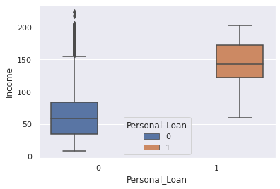

```python
# Let's look at a distribution of income for people who accept the Personal Loan vs. those who don't
sns.boxplot(x=df.Personal_Loan, y=df.Income, hue=df.Personal_Loan);
```

### Observations

- Those how accept personal loans appear to have higher incomes with the majority of them in the USD 125K to USD 175K range.
- Those who don't accept personal loans tend to be in the lower income group, although plenty of outliers exist above the USD 150K range who don't accept personal loans.
- Bank will need to find ways to engage with these people, and different campaigns may be needed to engage people at different income levels.

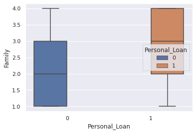

```python
# Let's look at a distribution of family size for people who accept the Personal Loan vs. those who don't
sns.boxplot(x=df.Personal_Loan, y=df.Family, hue=df.Personal_Loan);
```

```
Personal_Loan     0    1   All
Family
All            4520  480  5000
4              1088  134  1222
3               877  133  1010
1              1365  107  1472
2              1190  106  1296
------------------------------------------------------------------------------------------------------------------------
```

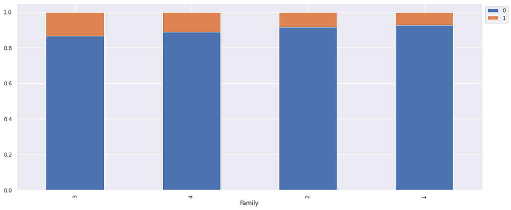

```python
stacked_plot(df.Family, df.Personal_Loan, 1)
```

### Family size

It is apparent that the bigger family size of 3 and 4 are the people who tend to accept personal loans more often. This seems reasonable since when you have children, their educational and other needs may cause additional monetary needs and this leads to personal loans. It is possible that there are other needs like home improvement, etc. for larger families that lead to personal loans.

We do not have data to see what other factors might influence larger families to need more personal loans.

However, the bank probably should target individuals with family size of 3-4 to sell more personal loans.

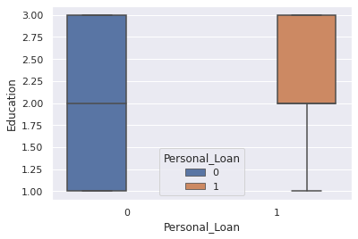

```python
# Let's look at a distribution of Education level for people who accept the Personal Loan vs. those who don't
sns.boxplot(x=df.Personal_Loan, y=df.Education, hue=df.Personal_Loan);
```

```
Personal_Loan     0    1   All
Education
All            4520  480  5000
3              1296  205  1501
2              1221  182  1403
1              2003   93  2096
------------------------------------------------------------------------------------------------------------------------
```

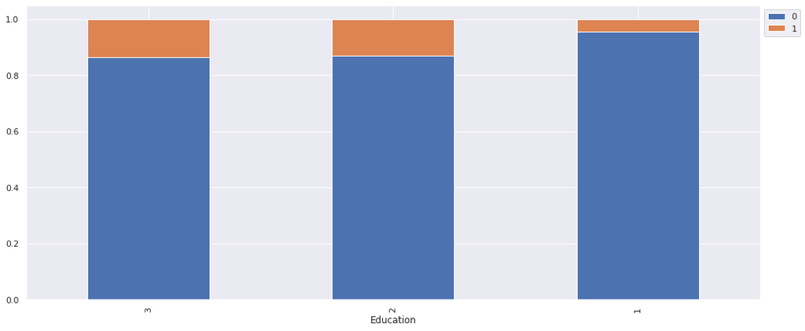

```python
stacked_plot(df.Education, df.Personal_Loan, 1)
```

### Education

- People with higher education level (graduate, advanced/professional) tend to take more personal loans.
- Bank should target individuals with higher degrees.

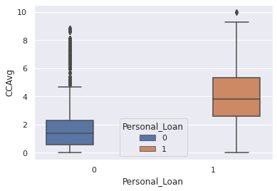

```python
# Let's look at a distribution of CCAvg for people who accept the Personal Loan vs. those who don't
sns.boxplot(x=df.Personal_Loan, y=df.CCAvg, hue=df.Personal_Loan);
```

### Observations

- Those how accept personal loans appear to have higher credit card balances with the majority of them in the USD 2.5K to USD 5K range.
- Those who don't accept personal loans tend to also have lower cedit card balances although plenty of outliers exist above the USD 4.5K range who don't accept personal loans.
- Bank will need to find ways to attract many of the people who keep higher credit card balances but do not accept personal loans. It will need to figure out what can motivate these people to take a personal loan.

##### Note

The relationship between CCAvg against aceepting/delcine loans is quite similar to that of the income distribution above. We also saw that there is a strong correlation between Income and CCAvg. Hence, I will drop the CCAvg column from the analysis.

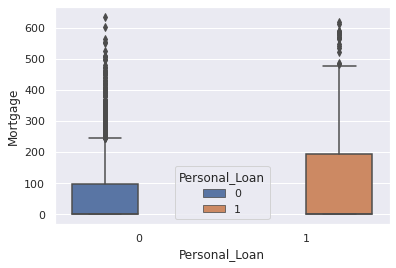

```python
# Let's look at a distribution of Mortgage balances for people who accept the Personal Loan vs. those who don't
sns.boxplot(x=df.Personal_Loan, y=df.Mortgage, hue=df.Personal_Loan);
```

```
Personal_Loan          0    1   All
Securities_Account
All                 4520  480  5000
0                   4058  420  4478
1                    462   60   522
------------------------------------------------------------------------------------------------------------------------
```

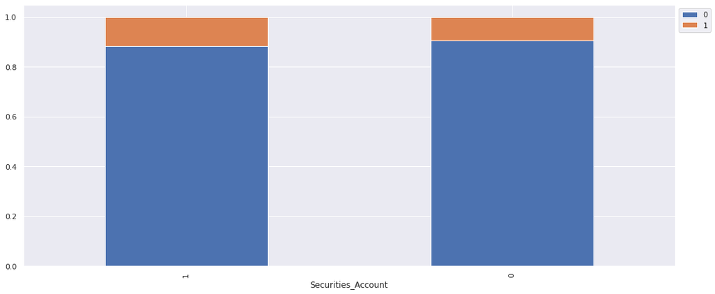

```python
# Let's look at a distribution of securities account for people who accept the Personal Loan vs. those who don't
stacked_plot(df.Securities_Account, df.Personal_Loan, 1)
```

### Securities account

Securities account doesn't seem to sway the decision for or against taking personal loans.

```
Personal_Loan     0    1   All
CD_Account
All            4520  480  5000
0              4358  340  4698
1               162  140   302
------------------------------------------------------------------------------------------------------------------------
```

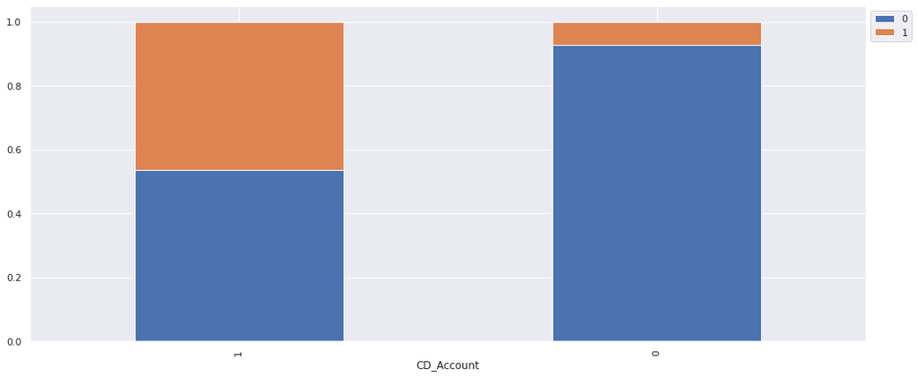

```python
# Let's look at a distribution of CD account for people who accept the Personal Loan vs. those who don't
stacked_plot(df.CD_Account, df.Personal_Loan, 1)
```

### CD Accounts

People who own CD accounts are more likely to to take personal loans as well. Bank should target the customers who already have a CD account with the bank.

```
Online         0     1   All
CD_Account
All         2016  2984  5000
0           1997  2701  4698
1             19   283   302
------------------------------------------------------------------------------------------------------------------------
```

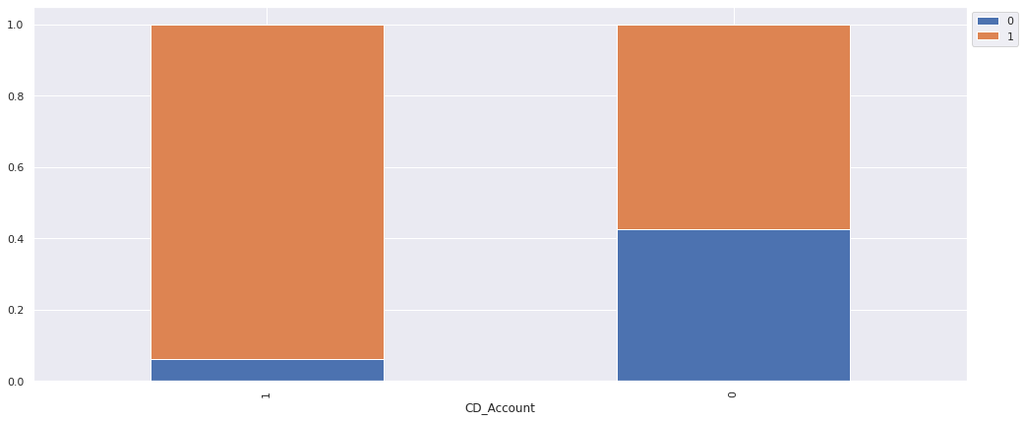

```python
# Let's look at a distribution of online customers for people who accept the Personal Loan vs. those who don't
stacked_plot(df.CD_Account, df.Online, 1)
```

### Online

```
Personal_Loan     0    1   All
CreditCard
All            4520  480  5000
0              3193  337  3530
1              1327  143  1470
------------------------------------------------------------------------------------------------------------------------
```

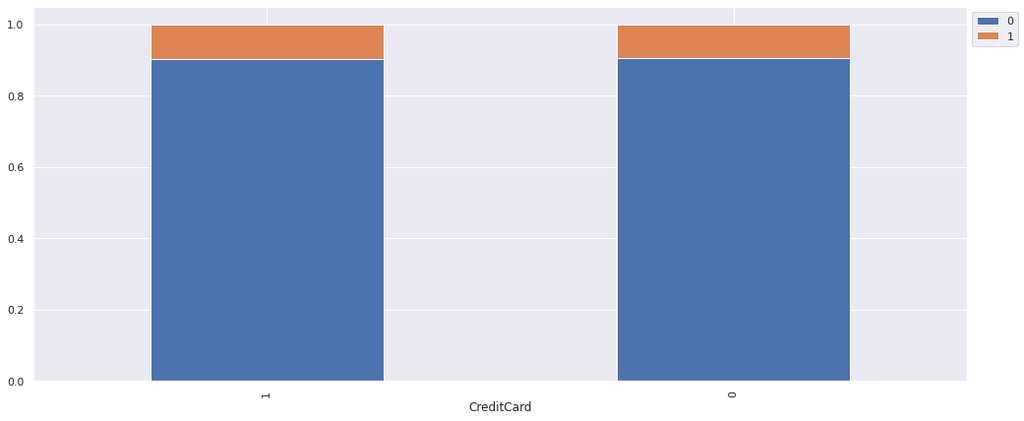

```python
# Let's look at a distribution of credit card from other bank for people who accept the Personal Loan vs. those who don't
stacked_plot(df.CreditCard, df.Personal_Loan, 1)
```

### Credit card from another bank

Credit card from another bank doesn't seem to significantly sway the decision one way or another in taking personal loans.

### Summary of EDA

- The data set for this project is quite clean and requires minimal data cleanup and feature engineering.
- We need to drop the ID column and the Experience columns from the data.
- Age and Experience have similar distribution of data and is normal distribution.
- Age and Experience have a very strong correlation (0.99), hence we have decided to drop Experience as a feature.
- Income distribution is right skewed, as expected, and has a few outliers. But they don't appear to be far out enought that anything needs to be dropped.

# Feature Engineering and Data Cleanup

```python
# First let's drop the columns that are not going to be useful for our anaysis.

# Drop ID since it has no relevance on the analysis
# Drop Experience since it has a very strong (0.99) correlation with Age
# Drop CCAvg since it has a strong (0.65) correlation with Income

cleaned = df.drop(['ID','Experience','CCAvg'],axis=1)
```

##### Note

We were initially thinking that we will need to do some data cleanup on Experience to replace all negative experience with 0, but since we have dropped the experience column, hence this cleanup is no longer necessary.

```python
# Veriy that the new data only has the columns that we are interested in
cleaned.info()
```

```
<class 'pandas.core.frame.DataFrame'>
RangeIndex: 5000 entries, 0 to 4999
Data columns (total 11 columns):
 #   Column              Non-Null Count  Dtype
---  ------              --------------  -----
 0   Age                 5000 non-null   int64
 1   Income              5000 non-null   int64
 2   ZIPCode             5000 non-null   int64
 3   Family              5000 non-null   int64
 4   Education           5000 non-null   int64
 5   Mortgage            5000 non-null   int64
 6   Personal_Loan       5000 non-null   int64
 7   Securities_Account  5000 non-null   int64
 8   CD_Account          5000 non-null   int64
 9   Online              5000 non-null   int64
 10  CreditCard          5000 non-null   int64
dtypes: int64(11)
memory usage: 429.8 KB
```

##### There is no further cleanup and feature engineering to be done as we were handed a very clean data set. We can move onto Logistic Regressions.

# Logistic Regressions

#### Goal of the predictions

Before we build the model and start doing the logistic regression, we need to be clear about what measures are most important to us.

We aim to give suggestion to bank on who is likely to be attracted to personal loans product, hence we will recommend going after those people - through advertisement, fliers, follow-ups, etc. That means that there is an investment the bank will need to make for people we identify as potential customers.

##### It is more important that our predictions of Positives be as accurate as possible. That means we have to focus more on the Precision (TP/(TP+FP)). Our goal is to get a high number for the precision.

In this case, Recall doesn't matter as much because even if we predict someone as Negative, but they end up buying a product, the bank did not invest in targeting those customers and got them for free.

Accuracy doesn't matter as much since we are not too concerned about the negative predictions.

##### Our goal will be to get a model with a high precision.

```python
X = cleaned.drop(['Personal_Loan'], axis=1)
Y = cleaned['Personal_Loan']

# Split the data into training set and test set in a 70/30 ratio
X_train, X_test, Y_train, Y_test = train_test_split(X,Y, test_size=0.30, random_state = 1)
```

```python
# Verify that the data has been split in a 70/30 ratio
X_train.shape
```

```
(3500, 10)
```

```python
X_test.shape
```

```
(1500, 10)
```

#### Handy functions

Let me first define some functions that will make it easy for me to look at results

```python
def showScores(y_actual, y_pred, type="Training") :
    '''
    A utility function to display the scores for either a test set or for a training set.
    Caller should send predicted and actual Y values for either a test set or for a training set, but not both.
    '''
    accuracy = metrics.accuracy_score(y_actual, y_pred)
    precision = metrics.precision_score(y_actual, y_pred)
    recall = metrics.recall_score(y_actual, y_pred)
    f1 = metrics.f1_score(y_actual, y_pred)

    print(type + " Set >>>>")
    print(f"       Accuracy: {accuracy}")
    print(f"       Recall: {recall}")
    print(f"       Precision: {precision}")
    print(f"       F1: {f1}")
```

```python
# This code has been adapted from code provided with the lectures.
def showConfusionMatrix(y_actual, y_pred) :
    '''
    A utility function to show the confusion matrix as a heat map. A caller should provide the predicted and
    actual Y values for either a training set or for a test set, but not both.
    '''
    cm=metrics.confusion_matrix(y_actual, y_pred, labels=[1, 0])

    df_cm = pd.DataFrame(cm, index = [i for i in ["Actual True","Actual False"]],
                         columns = [i for i in ["Predict True","Predict False"]])
    plt.figure(figsize = (10,7))
    sns.heatmap(df_cm, annot=True, fmt='')
```

##### Build the model

```python
logReg = LogisticRegression(solver='newton-cg',random_state=1)
model  = logReg.fit(X_train,Y_train)
```

##### Let's use the model to predict

```
Training Set >>>>
       Accuracy: 0.9528571428571428
       Recall: 0.6193353474320241
       Precision: 0.8401639344262295
       F1: 0.7130434782608696
```

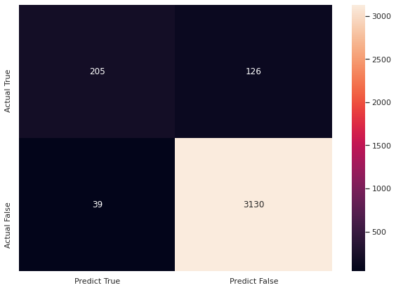

```python
# First let's apply the prediction on the training set, so that we can compare against the results on test set
Y_predict_train = model.predict(X_train)
showScores(Y_train, Y_predict_train)
showConfusionMatrix(Y_train, Y_predict_train)
```

```
Test Set >>>>
       Accuracy: 0.9446666666666667
       Recall: 0.5704697986577181
       Precision: 0.8173076923076923
       F1: 0.6719367588932806
```

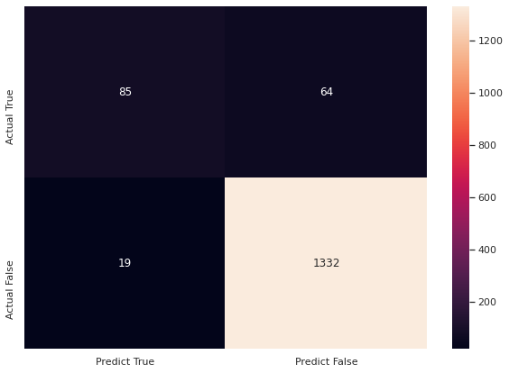

```python
# Now let's do the prediction on the test data set and see how good are the results
Y_predict_test = model.predict(X_test)
showScores(Y_test, Y_predict_test, "Test")
showConfusionMatrix(Y_test, Y_predict_test)
```

#### Observation and Interpretation.

The model appears to be a fairly good one as it provides a pretty high number for precision for both the training data (0.84) as well as the test data (0.82). This is a fairly reliable model and can be used target customers.

There is a little bit of overfitting going on because the precision on the test data is slighly lower than the results on the training data, but the difference is just 2%.

```python
# Let's understand the coefficients
log_odds = logReg.coef_[0]
pd.DataFrame(log_odds, X_train.columns, columns=['coef'])
```

|  | coef |
| --- | --- |
| Age | -0.000326 |
| Income | 0.055712 |
| ZIPCode | -0.000135 |
| Family | 0.703282 |
| Education | 1.586726 |
| Mortgage | 0.000539 |
| Securities_Account | -0.766604 |
| CD_Account | 3.258781 |
| Online | -0.510977 |
| CreditCard | -0.914366 |

The following coefficients are `positive`

- `Income`, `Family`, `Education`, `Mortgage`, `CD_Account`
- This means that a higher income, family size, or education level leads to higher chances of taking personal loan.
- It also means that people who have a mortgage, or CD account have a higher chance of taking personal loan.

The following coefficients are `negative`

- `Age`, `ZIPCode`, `Securities_Account`, `Online`, `CreditCard`
- This means that younger people a more likely to take personal loans, older customers are less likely.
- Certain zip codes are less likely to take personal loans.
- People who are usually online tend to not take personal loans - so invest in face-to-face interaction at the bank.
- People who have securities account are less likely to take personal loans, so do not cross-sell to them.
- People who have credit cards from other banks are less likely to take personal loans, perhaps because their short term loan needs are met by the credit cards.

```python
# Now let's convert the coefficients to change in odds
change_in_odds = (np.exp(logReg.coef_[0])-1)*100 # finding the percentage change
pd.DataFrame(change_in_odds, X_train.columns, columns=['Odds Change%'])
```

|  | Odds Change% |
| --- | --- |
| Age | -0.032566 |
| Income | 5.729339 |
| ZIPCode | -0.013524 |
| Family | 102.037321 |
| Education | 388.772153 |
| Mortgage | 0.053954 |
| Securities_Account | -53.541202 |
| CD_Account | 2501.778955 |
| Online | -40.009065 |
| CreditCard | -59.922933 |

#### More interpretation of the coefficients in terms of change of odds

Not all features have the same impact.

# Recommendation to Bank based on Logistic Regression

Given the analysis, we make the following recommendations

1. Target all customers who have a CD account since they are the most likely to take a personal loan.
2. Target people will graduate degrees or higher in campaigns/fliers, and direct face-to-face contact.
3. Instead of spending time targeting singles, focus more on people with families, especially having at least one or more kids.
4. Pay attention to the people who visit the bank for regular teller transactions rather than using online options. Have managers engage with them since they are more likely to take a personal loan.

# Decision Tree

Now we will create a different model for the same data using decision tree and try arrive at a prediction.

```python
# First we need to get the correct set of feature columns for the decision (minus the target variable)
feature_names = list(cleaned.columns)
feature_names.remove('Personal_Loan')
print(feature_names)
```

```
['Age', 'Income', 'ZIPCode', 'Family', 'Education', 'Mortgage', 'Securities_Account', 'CD_Account', 'Online', 'CreditCard']
```

```python
dt_model = DecisionTreeClassifier(
    criterion="gini", class_weight={0: 0.15, 1: 0.85}, random_state=1
)
```

```python
# Let's train the model with the training data
dt_model.fit(X_train, Y_train)
```

```
DecisionTreeClassifier(class_weight={0: 0.15, 1: 0.85}, random_state=1)
```

```
Training Set >>>>
       Accuracy: 1.0
       Recall: 1.0
       Precision: 1.0
       F1: 1.0
```

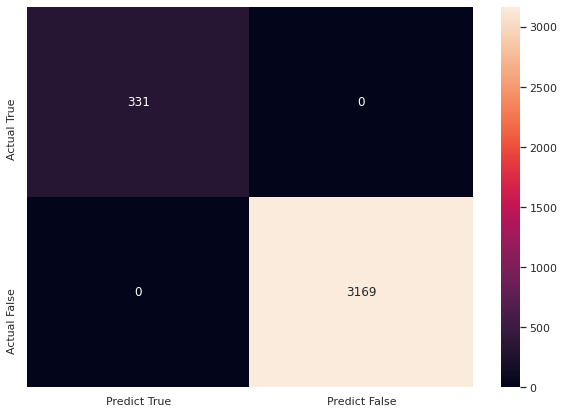

```python
# Let's study how well the decision tree works on the training data before running it against the test data
Y_predict_train = dt_model.predict(X_train)
showScores(Y_train, Y_predict_train)
showConfusionMatrix(Y_train, Y_predict_train)
```

```
Test Set >>>>
       Accuracy: 0.9626666666666667
       Recall: 0.7785234899328859
       Precision: 0.8345323741007195
       F1: 0.8055555555555557
```

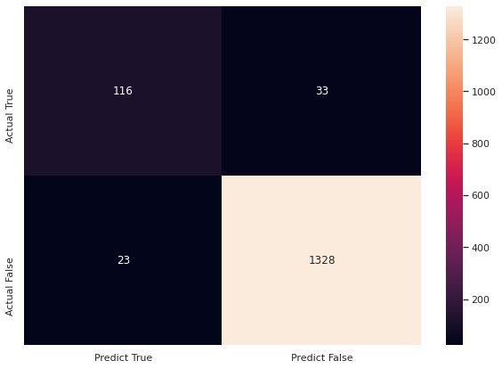

```python
# Now time to see how the model does with the test data
Y_predict_test = dt_model.predict(X_test)
showScores(Y_test, Y_predict_test, "Test")
showConfusionMatrix(Y_test, Y_predict_test)
```

### Observation

Although we got a fairly high number for the precision on the test data (0.83), the model is clearly overfitted since the precision is 1.0 for the training data. Also, there is a big difference between the precision number obtained from the training data vs. that obtained from the testing data.

This is because decision trees are prone to overfitting unless controlled.

```python
def plotDecisionTree(model, feature_names):
    '''
    Utility function to simplify plotting of decision tree
    '''
    plt.figure(figsize=(20, 30))
    out = tree.plot_tree(
            model,
            feature_names=feature_names,
            filled=True,
            fontsize=9,
            node_ids=False,
            class_names=None,
    )
    plt.show()
```

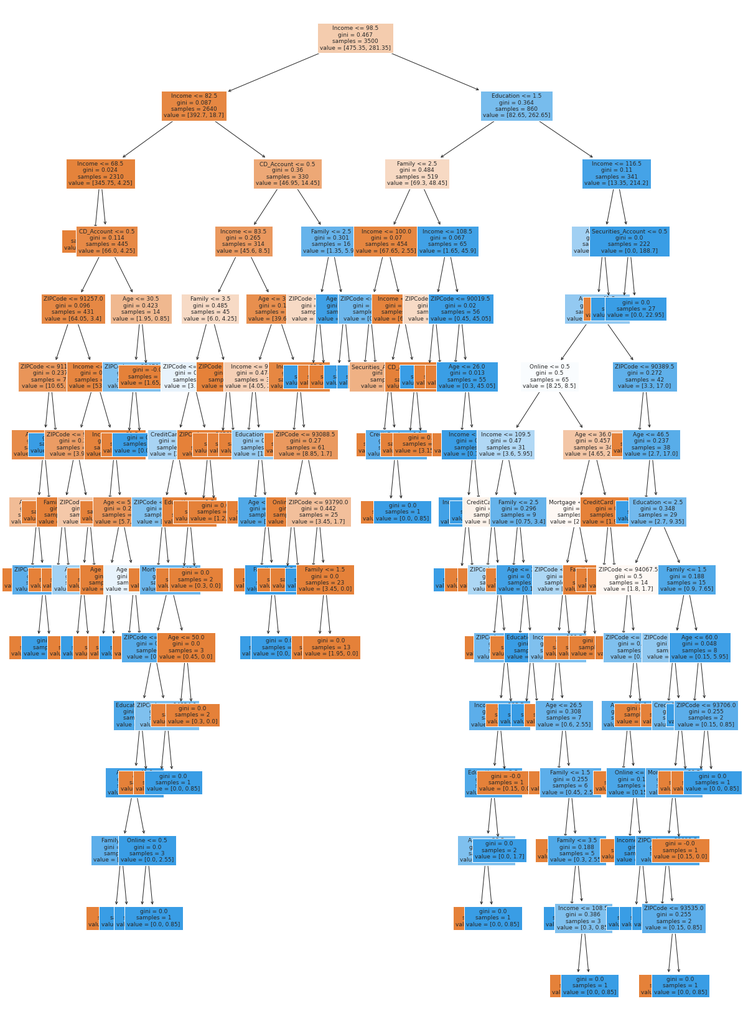

```python
# Let's plot the decision tree and see how complex it is
plotDecisionTree(dt_model, feature_names)
```

#### The tree is pretty big and complicated! We now need to build a new model that doesn't allow the tree to grow out of control.

```python
# Print the decision tree in all text
print(tree.export_text(dt_model, feature_names=feature_names, show_weights=True))
```

```
|--- Income <= 98.50
|   |--- Income <= 82.50
|   |   |--- Income <= 68.50
|   |   |   |--- weights: [279.75, 0.00] class: 0
|   |   |--- Income >  68.50
|   |   |   |--- CD_Account <= 0.50
|   |   |   |   |--- ZIPCode <= 91257.00
|   |   |   |   |   |--- ZIPCode <= 91164.00
|   |   |   |   |   |   |--- Age <= 33.00
|   |   |   |   |   |   |   |--- Age <= 31.50
|   |   |   |   |   |   |   |   |--- weights: [1.65, 0.00] class: 0
|   |   |   |   |   |   |   |--- Age >  31.50
|   |   |   |   |   |   |   |   |--- ZIPCode <= 90501.00
|   |   |   |   |   |   |   |   |   |--- weights: [0.15, 0.00] class: 0
|   |   |   |   |   |   |   |   |--- ZIPCode >  90501.00
|   |   |   |   |   |   |   |   |   |--- weights: [0.00, 0.85] class: 1
|   |   |   |   |   |   |--- Age >  33.00
|   |   |   |   |   |   |   |--- weights: [8.85, 0.00] class: 0
|   |   |   |   |   |--- ZIPCode >  91164.00
|   |   |   |   |   |   |--- weights: [0.00, 0.85] class: 1
|   |   |   |   |--- ZIPCode >  91257.00
|   |   |   |   |   |--- Income <= 69.50
|   |   |   |   |   |   |--- ZIPCode <= 94303.50
|   |   |   |   |   |   |   |--- Family <= 1.50
|   |   |   |   |   |   |   |   |--- weights: [0.15, 0.00] class: 0
|   |   |   |   |   |   |   |--- Family >  1.50
|   |   |   |   |   |   |   |   |--- weights: [2.25, 0.00] class: 0
|   |   |   |   |   |   |--- ZIPCode >  94303.50
|   |   |   |   |   |   |   |--- ZIPCode <= 94421.50
|   |   |   |   |   |   |   |   |--- Age <= 33.00
|   |   |   |   |   |   |   |   |   |--- weights: [0.45, 0.00] class: 0
|   |   |   |   |   |   |   |   |--- Age >  33.00
|   |   |   |   |   |   |   |   |   |--- weights: [0.00, 0.85] class: 1
|   |   |   |   |   |   |   |--- ZIPCode >  94421.50
|   |   |   |   |   |   |   |   |--- weights: [1.05, 0.00] class: 0
|   |   |   |   |   |--- Income >  69.50
|   |   |   |   |   |   |--- Income <= 81.50
|   |   |   |   |   |   |   |--- weights: [43.80, 0.00] class: 0
|   |   |   |   |   |   |--- Income >  81.50
|   |   |   |   |   |   |   |--- Age <= 52.00
```

[output cut: 222 more lines]

```
|   |   |   |   |   |   |   |   |--- Family >  1.50
|   |   |   |   |   |   |   |   |   |--- Age <= 60.00
|   |   |   |   |   |   |   |   |   |   |--- weights: [0.00, 5.10] class: 1
|   |   |   |   |   |   |   |   |   |--- Age >  60.00
|   |   |   |   |   |   |   |   |   |   |--- ZIPCode <= 93706.00
|   |   |   |   |   |   |   |   |   |   |   |--- weights: [0.15, 0.00] class: 0
|   |   |   |   |   |   |   |   |   |   |--- ZIPCode >  93706.00
|   |   |   |   |   |   |   |   |   |   |   |--- weights: [0.00, 0.85] class: 1
|   |   |   |--- Age >  63.50
|   |   |   |   |--- weights: [1.80, 0.00] class: 0
|   |   |--- Income >  116.50
|   |   |   |--- Securities_Account <= 0.50
|   |   |   |   |--- weights: [0.00, 165.75] class: 1
|   |   |   |--- Securities_Account >  0.50
|   |   |   |   |--- weights: [0.00, 22.95] class: 1
```

```python
# We will use GridSearchCV with different hyperparametes to come up with a smaller depth for the tree
# GridSearchCV needs a set of objects, which we will now create step by step before using that function.

# Choose the type of classifier.
estimator = DecisionTreeClassifier(random_state=1, class_weight={0: 0.15, 1: 0.85})

# Grid of parameters to choose from
parameters = {
    "max_depth": np.arange(1, 5),
    "criterion": ["gini"],
    "splitter": ["best", "random"],
    "min_impurity_decrease": [0.000001, 0.00001, 0.0001],
    "max_features": ["sqrt"],
}

# Type of scoring used to compare parameter combinations
scorer = metrics.make_scorer(metrics.recall_score)

# Run the grid search to find the best combination
grid_obj = GridSearchCV(estimator, parameters, scoring=scorer, cv=5)
grid_obj = grid_obj.fit(X_train, Y_train)

# Set the CLF to the best combination of parameters - this becomes the new decision tree model
estimator = grid_obj.best_estimator_

# Fit the best algorithm to the data.
estimator.fit(X_train, Y_train)

# New training is now complete
```

```
DecisionTreeClassifier(class_weight={0: 0.15, 1: 0.85}, max_depth=4,
                       max_features='sqrt', min_impurity_decrease=0.0001,
                       random_state=1)
```

Time to run the model of the training set and the test set once again to compare the results

```
Training Set >>>>
       Accuracy: 0.9657142857142857
       Recall: 0.9516616314199395
       Precision: 0.7517899761336515
       F1: 0.84
```

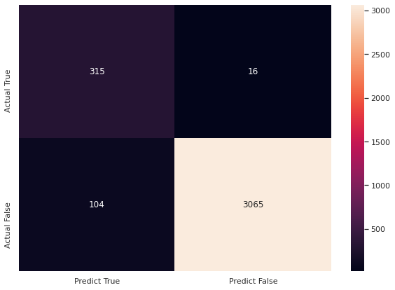

```python
# Let's study how well the NEW decision tree works on the training data before running it against the test data
Y_predict_train = estimator.predict(X_train)
showScores(Y_train, Y_predict_train)
showConfusionMatrix(Y_train, Y_predict_train)
```

```
Test Set >>>>
       Accuracy: 0.9626666666666667
       Recall: 0.7785234899328859
       Precision: 0.8345323741007195
       F1: 0.8055555555555557
```

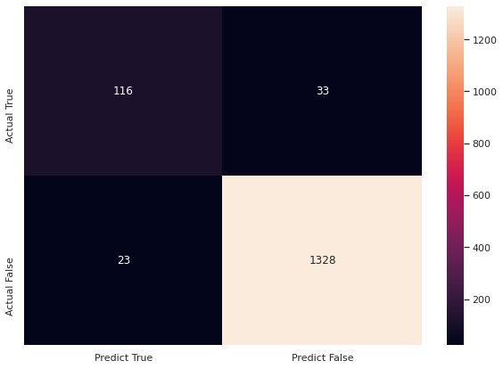

```python
# Now time to see how the NEW model does with the test data
Y_predict_test = dt_model.predict(X_test)
showScores(Y_test, Y_predict_test, "Test")
showConfusionMatrix(Y_test, Y_predict_test)
```

#### Observation

Also the recall of the training model is `0.952` whereas the recall on the test data is `0.779`.

There is quite a bit of discrepancy. Need to plot the new decision tree.

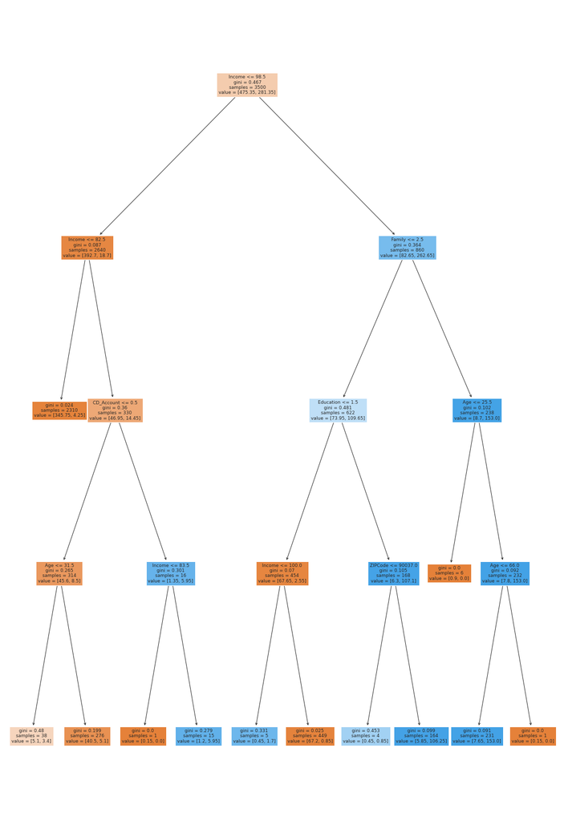

```python
plotDecisionTree(estimator, feature_names)
```

```python
# Print out the new decision tree in all text
print(tree.export_text(estimator, feature_names=feature_names, show_weights=True))
```

```
|--- Income <= 98.50
|   |--- Income <= 82.50
|   |   |--- weights: [345.75, 4.25] class: 0
|   |--- Income >  82.50
|   |   |--- CD_Account <= 0.50
|   |   |   |--- Age <= 31.50
|   |   |   |   |--- weights: [5.10, 3.40] class: 0
|   |   |   |--- Age >  31.50
|   |   |   |   |--- weights: [40.50, 5.10] class: 0
|   |   |--- CD_Account >  0.50
|   |   |   |--- Income <= 83.50
|   |   |   |   |--- weights: [0.15, 0.00] class: 0
|   |   |   |--- Income >  83.50
|   |   |   |   |--- weights: [1.20, 5.95] class: 1
|--- Income >  98.50
|   |--- Family <= 2.50
|   |   |--- Education <= 1.50
|   |   |   |--- Income <= 100.00
|   |   |   |   |--- weights: [0.45, 1.70] class: 1
|   |   |   |--- Income >  100.00
|   |   |   |   |--- weights: [67.20, 0.85] class: 0
|   |   |--- Education >  1.50
|   |   |   |--- ZIPCode <= 90037.00
|   |   |   |   |--- weights: [0.45, 0.85] class: 1
|   |   |   |--- ZIPCode >  90037.00
|   |   |   |   |--- weights: [5.85, 106.25] class: 1
|   |--- Family >  2.50
|   |   |--- Age <= 25.50
|   |   |   |--- weights: [0.90, 0.00] class: 0
|   |   |--- Age >  25.50
|   |   |   |--- Age <= 66.00
|   |   |   |   |--- weights: [7.65, 153.00] class: 1
|   |   |   |--- Age >  66.00
|   |   |   |   |--- weights: [0.15, 0.00] class: 0
```

```python
# Print the vamrious parameters to study the importance of each
print(
    pd.DataFrame(
        estimator.feature_importances_, columns=["Imp"], index=X_train.columns
    ).sort_values(by="Imp", ascending=False)
)
```

```
                         Imp
Income              0.663704
Education           0.237346
Family              0.069501
CD_Account          0.018482
Age                 0.010229
ZIPCode             0.000737
Mortgage            0.000000
Securities_Account  0.000000
Online              0.000000
CreditCard          0.000000
```

##### Observation

The important features are the same but the `Income` has been given the highest priority by the decision tree compared to the Logistic Regression model.

# Recommendation to Bank based on Decision Tree

Given the analysis, we make the following recommendations

1. Target the higher income customers, no matter what other characteristics or banking patterns they have. Given the model, the highest earners also have the highest likelihood of taking out personal loans.
2. Target people will graduate degrees or higher in campaigns/fliers, and direct face-to-face contact.
3. If you need to choose people to target based on family size, instead of spending time targeting singles, focus more on people with families, especially having at least one or more kids.
4. Target all customers who have a CD account since they are more likely to take a personal loan.
5. Target older people more in your campaigns rather than younger ones.

# Comparison of results from logistic regression and decision tree

The results between the logistic regressions and decision tree are somewhat similar with some key difference.

##### Dissimilarities of the models

- Whereas logistic regression model siad that people with CS accounts have the highest likelihood to taking personal loans, the decision tree model gave the highest importance to the people with higher incomes.
- LG asked us to give importance to people who visit the bank and not do online banking, but DT says that online banking is not significant.

##### Contradiction between the models

- The major contradiction is that LG says that older people are `less` likely to take loans whereas DT says that older people are `more` likely to take loans.